# Estudo de Caso: Indicadores de natalidade, fecundidade e mortalidade do Acre (2000-2020)

Demografia - Profa. Ana Maria Nogales

Ana Luiza Almeida

Bruno Gondim Toledo

César A. Galvão

Hermes Winarski

Brasília, Setembro/2021

## Questão 1: Diagrama de Lexis

### Item a

O diagrama de Lexis para os dados de nascidos vivos de 2000 a 2020 do Acre (SINASC) e de óbitos menores de 5 anos (idades simples) para o mesmo período segundo ano de nascimento é exposto a seguir:

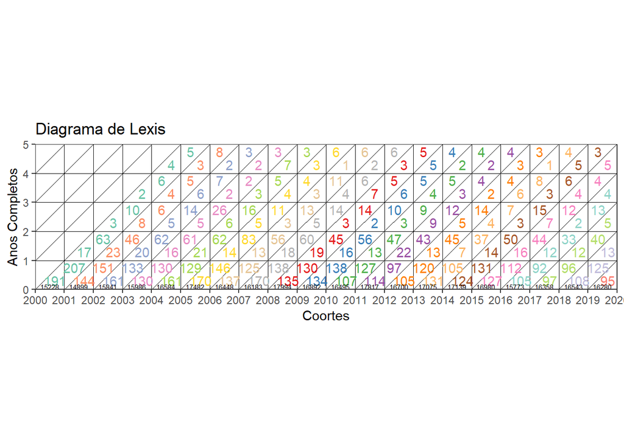

### Item b

Supondo população fechada (inexistência de migração), foi calculada a probabilidade de um recém-nascido na UF ou território de escolha sobreviver à idade exata 5 para as coortes de 2000 a 2015.

Foram observados 6.260 indivíduos nascidos vivos e posteriormente falecidos no intervalo de 2000 a 2015, enquanto registra-se 265.743 indivíduos nascidos no mesmo intervalo. Logo a probabilidade de sobrevivência é:

### Item c

Considerando o mesmo pressuposto, a probabilidade de sobrevivência ao primeiro aniversário dos recém-nascidos no período de 2000 a 2019. é calculada a seguir.

Foram observados 5.190 óbitos em menores de 1 ano no intervalo de 2000 a 2019, enquanto registra-se 330.697 nascimentos no mesmo intervalo. Logo, a probabilidade de sobrevivência ao primeiro aniversário foi é:

$$P(\text{sobrevivência ao primeiro aniversário})_{2000-2019} = 1 - \frac{5.190}{330.697} = 0.98$$

### Item d

Os bancos de dados utilizados para a elaboração das questões estavam, em sua marioria, completos em relação às variáveis utilizadas, não sendo comum encontrar valores em branco.

Porém, não há como se ter certeza se os dados trabalhados refletem a totalidade dos casos de nascimentos e mortes ocorridos, visto que pode haver fuga de registro. Além disso, foram observados alguns valores impossíveis (ex: nascido em 2000 com 70 anos de idade), porém foram poucos e o que é de se esperar em grandes bancos de dados.

Início

## Questão 2: Natalidade/Fecundidade

### Item a

Com base nos dados do SINASC, para os anos de 2018 a 2020 e na população por sexo e idade estimada - ou seja, projetando o ano de 2019 - foram construídos os seguintes indicadores para o estado do Acre

|  | X2018 | X2019 | X2020 |
| --- | --- | --- | --- |
| Taxa Bruta de Natalidade | 19.0310205 | 18.4594103 | 16.4767963 |
| Taxa Geral de Fecundidade | 68.7478442 | 66.4267470 | 59.0606716 |
| Taxa de Fecundidade Total | 0.9758085 | 0.9598756 | 0.8663531 |
| Taxa Bruta de Reprodução | 0.4755542 | 0.4616512 | 0.4199713 |
| Taxa Líquida de Reprodução | 0.4638397 | 0.4506160 | 0.4101096 |

| GRUPO.ETARIO | freqnasc18 | 2018 | TEF18 |
| --- | --- | --- | --- |
| 15-19 | 3498 | 45347 | 77.13850971 |
| 20-24 | 2602 | 41526 | 62.65953860 |
| 25-29 | 1581 | 36873 | 42.87690180 |
| 30-34 | 392 | 34721 | 11.28999741 |
| 35-39 | 35 | 32723 | 1.06958408 |
| 40-44 | 1 | 27380 | 0.03652301 |
| 45-49 | 2 | 22063 | 0.09064950 |

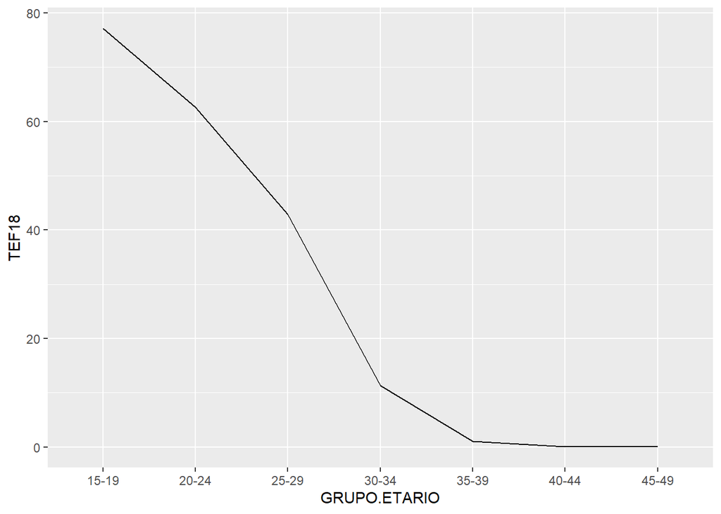

| GRUPO.ETARIO | freqnasc19 | 2019 | TEF19 |
| --- | --- | --- | --- |
| 15-19 | 3480 | 45423 | 76.6131695 |
| 20-24 | 2592 | 42454 | 61.0543176 |
| 25-29 | 1544 | 37617 | 41.0452721 |
| 30-34 | 417 | 34826 | 11.9738127 |
| 35-39 | 36 | 33374 | 1.0786840 |
| 40-44 | 6 | 28590 | 0.2098636 |
| 45-49 | 0 | 22798 | 0.0000000 |

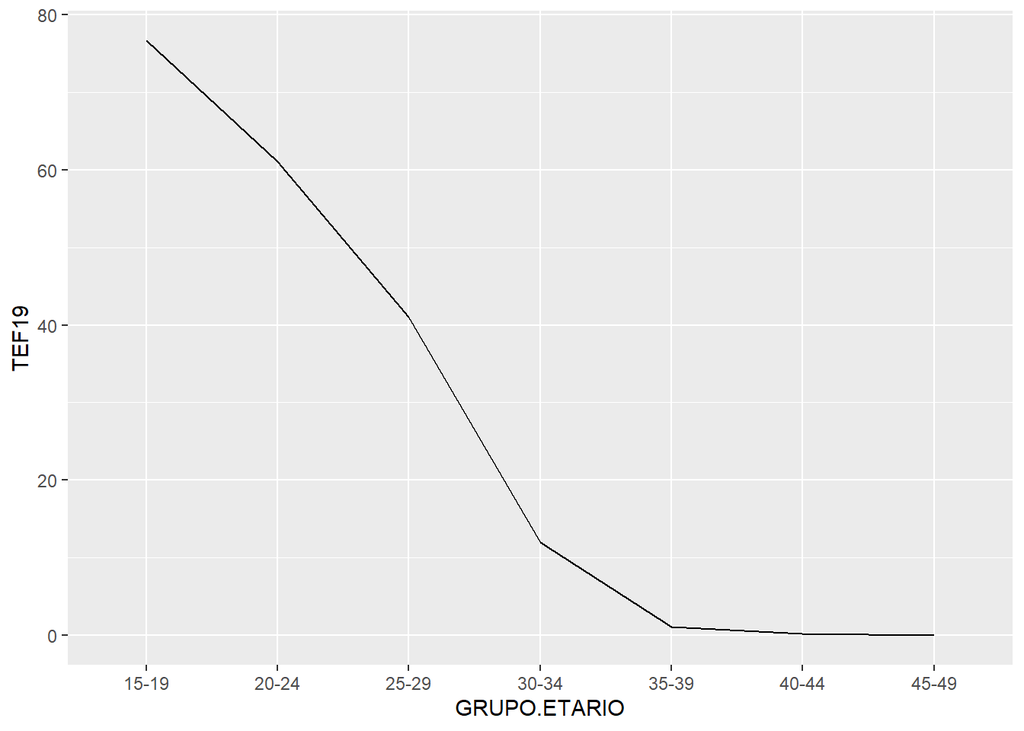

| GRUPO.ETARIO | freqnasc20 | 2020 | TEF20 |
| --- | --- | --- | --- |
| 15-19 | 3072 | 45538 | 67.46014318 |
| 20-24 | 2414 | 43258 | 55.80470664 |
| 25-29 | 1445 | 38432 | 37.59887594 |
| 30-34 | 401 | 35075 | 11.43264433 |
| 35-39 | 27 | 33865 | 0.79728333 |
| 40-44 | 4 | 29686 | 0.13474365 |
| 45-49 | 1 | 23686 | 0.04221903 |

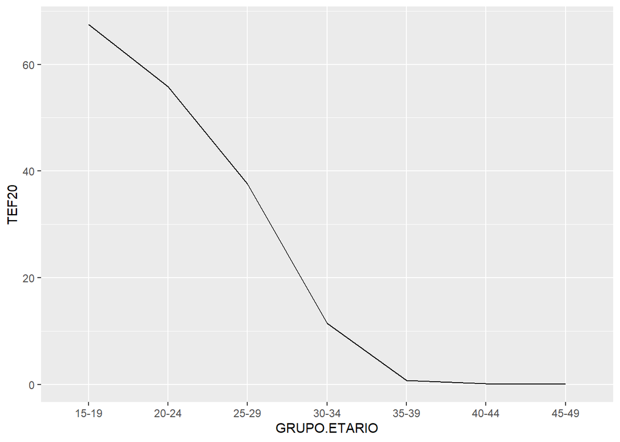

| GRUPO.ETARIO | freqnascfem18 | 2018 | TEFfem18 |
| --- | --- | --- | --- |
| 15-19 | 1725 | 45347 | 38.04000265 |
| 20-24 | 1266 | 41526 | 30.48692385 |
| 25-29 | 763 | 36873 | 20.69264774 |
| 30-34 | 186 | 34721 | 5.35698857 |
| 35-39 | 16 | 32723 | 0.48895272 |
| 40-44 | 0 | 27380 | 0.00000000 |
| 45-49 | 1 | 22063 | 0.04532475 |

| GRUPO.ETARIO | freqnascfem19 | 2019 | TEFfem19 |
| --- | --- | --- | --- |
| 15-19 | 1688 | 45423 | 37.1617903 |
| 20-24 | 1268 | 42454 | 29.8676214 |
| 25-29 | 715 | 37617 | 19.0073637 |
| 30-34 | 203 | 34826 | 5.8289783 |
| 35-39 | 12 | 33374 | 0.3595613 |
| 40-44 | 3 | 28590 | 0.1049318 |
| 45-49 | 0 | 22798 | 0.0000000 |

| GRUPO.ETARIO | freqnascfem20 | 2020 | TEFfem20 |
| --- | --- | --- | --- |
| 15-19 | 1416 | 45538 | 31.09490975 |
| 20-24 | 1186 | 43258 | 27.41689398 |
| 25-29 | 742 | 38432 | 19.30682764 |
| 30-34 | 203 | 35075 | 5.78759800 |
| 35-39 | 12 | 33865 | 0.35434815 |
| 40-44 | 1 | 29686 | 0.03368591 |
| 45-49 | 0 | 23686 | 0.00000000 |

### Item b

|  | Sinasc2018 | GBD2018 | Sinasc2019 | GBD2019 | Sinasc2020 | RIPSA |
| --- | --- | --- | --- | --- | --- | --- |
| Taxa de Fecundidade Total | 0.9758085 | 1.9721657617401 | 0.9598756 | 1.9571808072133 | 0.8663531 | 2,81 |
| Taxa Bruta de Natalidade | 19.0310205 | - | 18.4594103 | - | 16.4767963 | 26,69 |

#### Taxas de fecundidade específicas

##### RIPSA

| UF | 15 a 19 anos | 20 a 24 anos | 25 a 29 anos | 30 a 34 anos | 35 a 39 anos | 40 a 44 anos | 45 a 49 anos |
| --- | --- | --- | --- | --- | --- | --- | --- |
| Acre | 0,1235 | 0,1532 | 0,1261 | 0,0883 | 0,0519 | 0,0167 | 0,0027 |

##### GBD

| 2018 | val | upper | lower |
| --- | --- | --- | --- |
| 10 to 14 | 0.00328747128 | 0.0068214352 | 0.00145455498 |
| 15 to 19 | 0.07167660591 | 0.0940336707 | 0.05423429379 |
| 20 to 24 | 0.12585269336 | 0.1457127947 | 0.10818394370 |
| 25 to 29 | 0.07124752442 | 0.0783265192 | 0.06457097865 |
| 30 to 34 | 0.07119281032 | 0.0803078676 | 0.06293284919 |
| 35 to 39 | 0.02953655310 | 0.0347905813 | 0.02484704971 |
| 40 to 44 | 0.02077921919 | 0.0245670312 | 0.01724905700 |
| 45 to 49 | 0.00083189283 | 0.0011345296 | 0.00058485334 |
| 50 to 54 | 0.00002838193 | 0.0000293462 | 0.00002739185 |

| 2019 | val | upper | lower |
| --- | --- | --- | --- |
| 10 to 14 | 0.00325971355 | 0.00676231337 | 0.0014426879 |
| 15 to 19 | 0.07086495780 | 0.09390062110 | 0.0528354507 |
| 20 to 24 | 0.12367543367 | 0.14381330824 | 0.1054565213 |
| 25 to 29 | 0.07149937957 | 0.07911376527 | 0.0644803584 |
| 30 to 34 | 0.07110257313 | 0.08075998327 | 0.0623954349 |
| 35 to 39 | 0.02968370323 | 0.03545258063 | 0.0246549843 |
| 40 to 44 | 0.02050493744 | 0.02481204752 | 0.0167615416 |
| 45 to 49 | 0.00081760783 | 0.00113785646 | 0.0005621933 |
| 50 to 54 | 0.00002785521 | 0.00002880158 | 0.0000268835 |

##### SINASC

| GRUPO.ETARIO | freqnasc18 | 2018 | TEF18 |
| --- | --- | --- | --- |
| 15-19 | 3498 | 45347 | 0.00007713850971 |
| 20-24 | 2602 | 41526 | 0.00006265953860 |
| 25-29 | 1581 | 36873 | 0.00004287690180 |
| 30-34 | 392 | 34721 | 0.00001128999741 |
| 35-39 | 35 | 32723 | 0.00000106958408 |
| 40-44 | 1 | 27380 | 0.00000003652301 |
| 45-49 | 2 | 22063 | 0.00000009064950 |

| GRUPO.ETARIO | freqnasc19 | 2019 | TEF19 |
| --- | --- | --- | --- |
| 15-19 | 3480 | 45423 | 0.0000766131695 |
| 20-24 | 2592 | 42454 | 0.0000610543176 |
| 25-29 | 1544 | 37617 | 0.0000410452721 |
| 30-34 | 417 | 34826 | 0.0000119738127 |
| 35-39 | 36 | 33374 | 0.0000010786840 |
| 40-44 | 6 | 28590 | 0.0000002098636 |
| 45-49 | 0 | 22798 | 0.0000000000000 |

| GRUPO.ETARIO | freqnasc20 | 2020 | TEF20 |
| --- | --- | --- | --- |
| 15-19 | 3072 | 45538 | 0.00006746014318 |
| 20-24 | 2414 | 43258 | 0.00005580470664 |
| 25-29 | 1445 | 38432 | 0.00003759887594 |
| 30-34 | 401 | 35075 | 0.00001143264433 |
| 35-39 | 27 | 33865 | 0.00000079728333 |
| 40-44 | 4 | 29686 | 0.00000013474365 |
| 45-49 | 1 | 23686 | 0.00000004221903 |

#### Indicador de reprodução

| A.5 Taxa de fecundidade total | ...40 |
| --- | --- |
| UF | 2010 |
| Acre | 2,81 |

```
## [1] 1.370732
```

### Item d

A primeira coisa a ser comentada é o fato de que ano a ano as taxas de natalidade e fecundidade vão diminuindo. Segundo o artigo “Transição demográfica: a experiência brasileira”, a queda dessas taxas indica que o Acre está passando pelo processo de transição demográfica, tendo em vista que esse processo não foi se desenvolvendo homogeneamente pelo território brasileiro. Existem muitos fatores que podem ter influenciado essa queda brusca dos indicadores de natalidade e fecundidade - como é visto no artigo “A demografia brasileira e o declínio da fecundidade no Brasil: contribuições, equívocos e silêncios”, mas um fato bem pontuado em praticamente todos os estudiosos do assunto é o de que o perfil das pessoas de baixa renda mudou. Alguns atribuem essa mudança a altas cargas de trabalho, outros a uma exaustão e cansaço, e outros a um nível maior de educação sexual e de educação no geral, mas todo giram em torno da mudança da rotina dessa “classe trabalhadora”.

Outra coisa que seria de interesse pontuar seriam as taxas específicas de fecundudade. Ao passo que uma transição demográfica mostraria que a idade prevalente das pessoas que estão engravidando e dando à luz, vemos que as taxas calculadas mostram que há uma maior quantidade de mães no Acre de 15 a 19 anos. Essa gravidez precoce pode estar relacionado com o fato de que o Acre é uma unidade federativa com uma dos menores IDH’s(20º de 26), isso mostraria que a população não tem um bom acesso a uma educação de qualidade e muito menos a uma educação sexual de qualidade, isso é mais discutido no artigo “Gravidez na adolescência, iniciação sexual e gênero: perspectivas em disputa”.

As discrepâncias que ocorreram entre os indicadores do RIPSA e do GBD podem ser devidas ao fato de que esses dois fizeram estimativas para os indicadores estudados. Contudo, existe uma transição demográfica e da fecundidade ocorrendo no local de forma extremamente rápida e constante, o que pode não ter sido avaliado pelos dois estudos.

Início

## Questão 3: Mortalidade

### Item b

As taxas de mortalidade infantil, neonatal, neonatal precoce, neonatal tardio, pós neonatal, neonatal perinatal e óbitos fetais foram calculadas utilizando dados do SIM, com média móvel de três anos centrada em 2019.

| Dados | Infantil | Neonatal | Neonatal Precoce | Neonatal Tardia | Pós Neonatal | Neonatal Perinatal | Obitos Fetais |
| --- | --- | --- | --- | --- | --- | --- | --- |
| Acre 2018-2020 | 15.62 | 9.21 | 6.86 | 2.35 | 6.18 | 20.95 | 3.5 |

Fonte: Ministério da Saúde - SIM

### Item c

Comparação das taxas de mortalidade obtidas com os dados do RIPSA e GBD

##### Tabela

| Dados | Infantil | Neonatal | Neonatal Precoce | Neonatal Tardia | Pós Neonatal | temp | tipo |
| --- | --- | --- | --- | --- | --- | --- | --- |
| Norte 1991 | 42.30 | 22.60 | 18.10 | 4.50 | 21.70 | 0 | RIPSA |
| Norte 1997 | 32.20 | 20.60 | 16.50 | 4.10 | 11.60 | 1 | RIPSA |
| Norte 2000 | 28.70 | 18.70 | 14.80 | 3.90 | 10.10 | 2 | RIPSA |
| Norte 2004 | 25.50 | 16.30 | 12.80 | 3.50 | 8.20 | 3 | RIPSA |
| Acre 2018-2020 | 15.62 | 9.21 | 6.86 | 2.35 | 6.18 | 4 | Demografia 1/2021 |

Fonte: Ministério da Saúde - SIM

##### Infantil

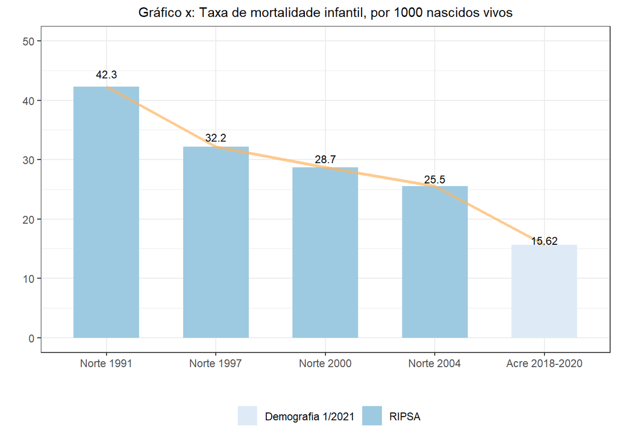

##### Neonatal

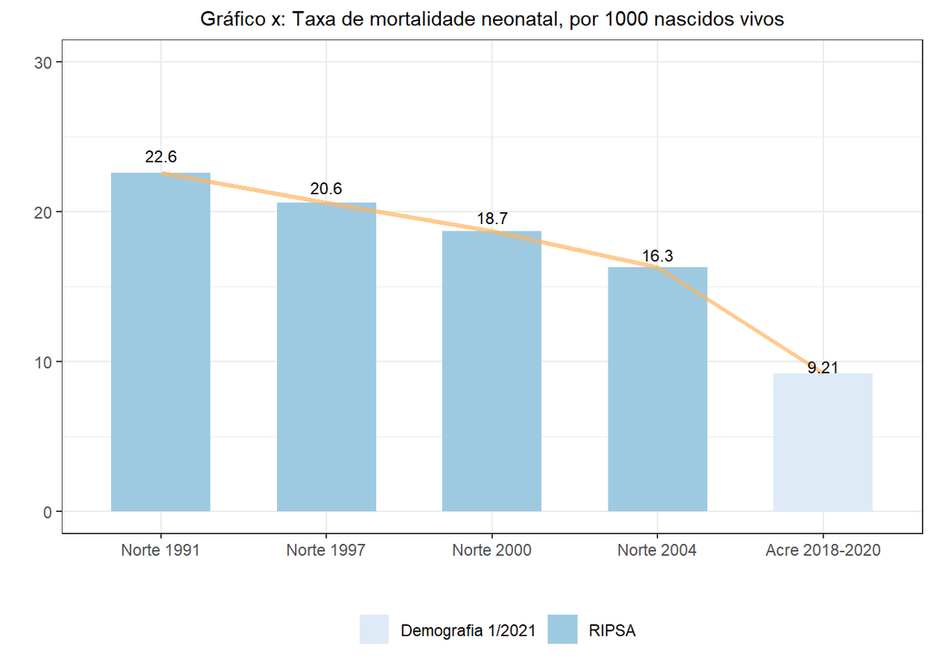

##### Neonatal Precoce

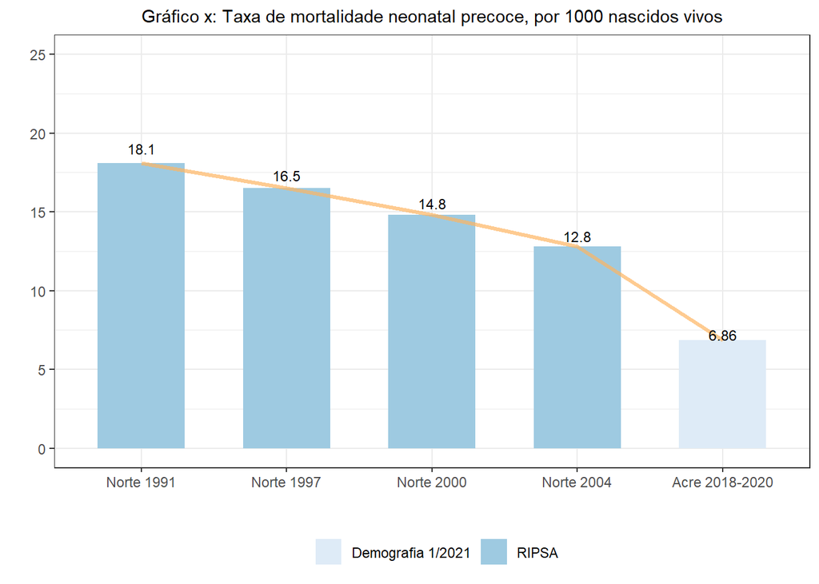

##### Neonatal Tardia

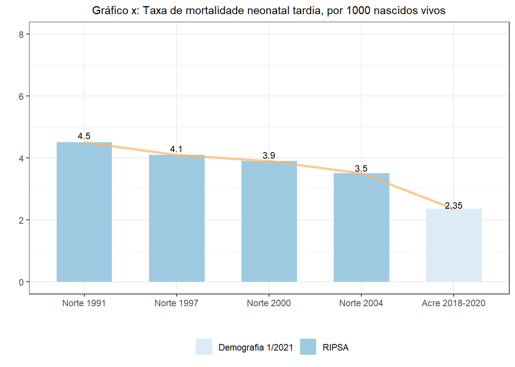

##### Pós Neonatal

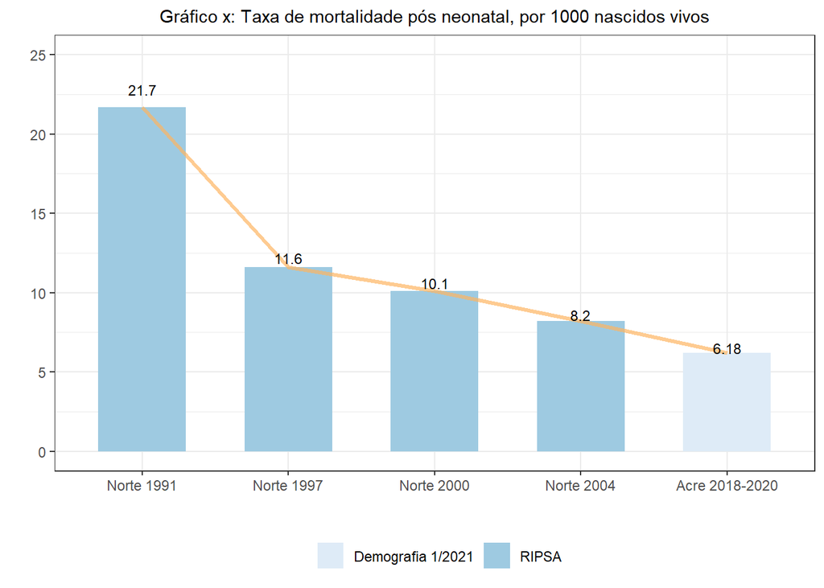

### Item d

A estrutura de mortalidade por causas segundo sexo, de 2015 e 2020, é exposta abaixo em formato de gráfico na primeira aba – expondo simplesmente as tendências – e em formato de tabela dinâmica na segunda aba – possibilitando uma investigação mais detalhada. O agrupamento feito abaixo é realizado de acordo com os capítulos da CID-10, sendo exibidos os mais frequentes.

Inicialmente é possível notar muitas comunalidades, tanto de tendência quanto de ordem, como é o caso de Sintomas e Achados Anormais, Doenças Infecciosas e Parasitárias, Doenças do Aparelho Respiratório e Doenças do Aparelho Circulatório. Em contraste, as principais divergências ocorrem quanto a Causas Externas, predominante na população masculina, e Complicações do Período Perinatal, que ocorre estritamente na população feminina.

No entanto, cabe notar que em 2020 começam a ser diagnosticados os casos de COVID-19, registrados em vermelho no ano de 2020. É possível que o aumento do registro de causas de morte cujos sintomas são semelhantes à doença tenha ocorrido por falta de consenso do código a ser utilizado e do diagnóstico. Cabe ressaltar ainda o cenário social e político que caracterizou o país durante os anos de 2019 a 2021, podendo ser também um contexto que favorece a ação de outras variáveis intervenientes quanto à quantidade de registros de *causa mortis* COVID-19.

Cabe ainda ressaltar que em todas as causas de morte listadas que poderiam ocorrer para ambos os sexos, ocorre sempre uma maior mortalidade na população masculina. Em especial no ano de 2020, enquanto na população feminina do Acre sequer constam nas maiores causas, mortes por lesões, envenenamentos ou outras causas externas são a quarta maior causa de morte na população masculina.

Por fim, visando investigar as causas de morte desagregadas em termos de CID, a tabela constante na terceira aba à direita foi produzida, também separando a população por sexo e os anos de comparação propostos. Apenas na população masculina aparece Coronavirus como uma das principais causas de morte em 2020. No entando, como já elaborado, outros registros de causa de morte podem ter sido atribuídos, por diversas causas, de maneira enviesada, visto que há CID com características semelhantes à COVID-19.

##### Gráficos causas de morte

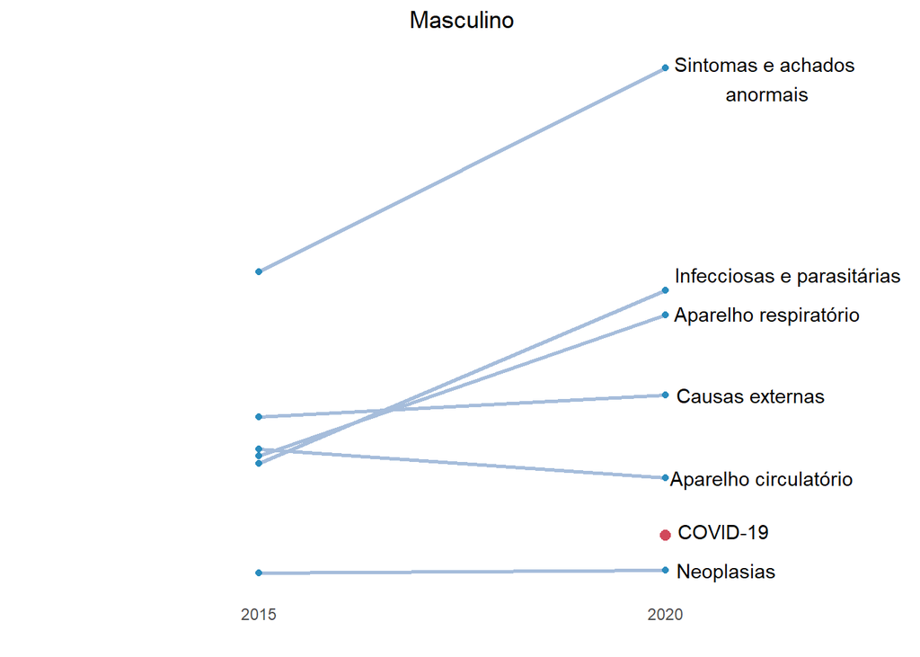

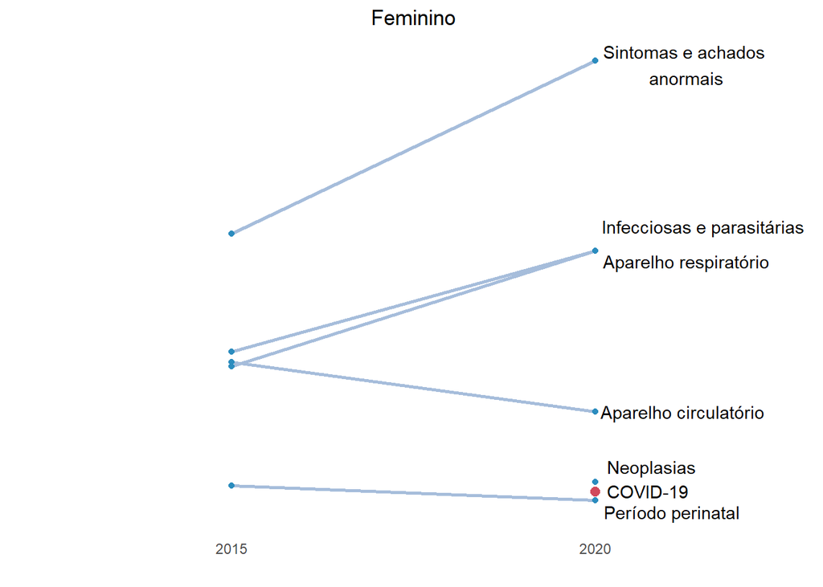

Fonte: Ministério da Saúde - SIM

##### Tabela causas de morte

[interactive table not shown]

##### Tabela causas de morte por CID

[interactive table not shown]

Início